# Cohort Indicator Extension: Evaluation Report

Supervised Bayesian Matrix Factorization — Cohort-cols-L Branch (2026-05-22)

Author

Andrew Walther

Published

May 22, 2026

# Executive Summary

This report evaluates the **cohort indicator extension** to the Supervised Bayesian Matrix Factorization (SSBMF) model, implemented on the `cohort-cols-L` branch (2026-05-22). The extension appends $C-1$ fixed binary columns to the loading matrix $L$, paired with cohort-specific factor rows in $F$. The columns absorb platform mean shifts without contaminating the survival linear predictor, which continues to use only the $K$ biological columns.

**Where it falls short:**

- On real PDAC data with $K=20$, the cohort indicator trades one biological factor for one platform factor ($K_\text{eff}=2$ vs 3 for LB_base), causing modest losses on Dijk ($-0.045$) and Puleo ($-0.044$). Mean external C-index: **0.604** (LB_cohort) vs **0.618** (LB_base) vs **0.609** (main-branch reference).
- YFB $\beta \to 0$ collapse on merged TCGA+CPTAC data is **not resolved** by the cohort extension ($K_\text{eff} = 0$ for both YFB_base and YFB_cohort).
- The CPTAC proteomics platform effect is non-linear and higher-rank; a single linear cohort indicator column cannot fully capture it.

**Recommendation:** The extension is most valuable at **low $K$ regimes** ($K \leq 5$) where platform effects and biology compete for the same factor budget. In this regime, the cohort indicator allows the model to converge with non-zero $\beta$ under short iteration budgets. At high $K$ ($K=20$), ARD pruning already handles platform effects implicitly, making the explicit cohort column redundant or marginally harmful.

# Background

## Motivation

Merged TCGA_PAAD ($n=144$, RNA-seq) and CPTAC ($n=129$, proteomics) training presents a substantial platform shift. In principal component analysis, the top component separates platforms rather than biology. In the LB model ($\eta = L\beta$), the CAVI solution can dedicate one or more of the $K$ biological factors to absorbing this platform offset, reducing the budget available for survival-predictive programs. In the YFB model ($\eta = (YF)\beta$), the platform component swamps the survival signal in the $L$ update ($A_\text{surv}/A_\text{gen} \sim 10^{-4}$), driving $\beta \to 0$.

## The Bayesian LMM Formulation

The augmented model appends a fixed design matrix $\tilde{L}_\text{cohort} \in \{0,1\}^{n \times (C-1)}$ (corner-point encoding; reference cohort = first alphabetical level) to $L$:
$$Y \approx L_\text{aug} F_\text{aug}^\top = \underbrace{L F^\top}_{\text{biological}} +
\underbrace{\tilde{L}_\text{cohort} F_\text{cohort}^\top}_{\text{platform offset}}$$
The Cox linear predictor is restricted to the biological subspace:
$$\eta_i = \ell_i^\top \beta, \quad \beta \in \mathbb{R}^K \quad (\beta_\text{cohort} = 0)$$
Each row $f_c$ of $F_\text{cohort}$ is given a Normal prior $f_c \sim \mathcal{N}(0, \sigma_{F,c}^2 I_p)$ and updated via the closed-form Normal conjugate:
$$\text{Var}_q(f_{c,j}) = \left( \frac{n_c \hat{\tau}_j}{\sigma_{F,c}^{-2} + n_c \hat{\tau}_j} \right) \cdot \frac{1}{n_c \hat{\tau}_j},
\quad
\mathbb{E}_q[f_{c,j}] = \text{Var}_q(f_{c,j}) \cdot \hat{\tau}_j \cdot \ell_c^\top R_j^{(-c)}$$
where $R_j^{(-c)}$ is the residual of gene $j$ after removing all biological and other cohort columns.

## New Code

| File | What was added |
| --- | --- |
| `code/update_F_cohort.R` | `update_F_cohort_k()` and `update_F_cohort_all()` — Normal conjugate update |
| `code/compute_elbo.R` | `compute_normal_kl()` — KL divergence for cohort factor prior |
| `code/fit_modular.R` | `cohort_id`, `sigma_F_cohort` params; full ELBO includes cohort KL |
| `code/fit_cox_on_yf.R` | Same; ZF restricted to K biological columns in two locations |

# Stage 1: Synthetic Validation

## Data Generating Process

```
n=200, p=500, K_true=3, C=2 cohorts, OFFSET_SD=2.0, SIGNAL_SD=0.5
Factor 1 is survival-aligned (β_true = [1, 0, 0])
Cohort assignment interleaved by risk rank (stratified, not confounded with survival)
Censoring calibrated to 30% event rate
```

Five models are compared:

- **LB_base** — LB ($\eta = L\beta$), no cohort adjustment
- **LB_cohort** — LB + `cohort_id` (corner-point column)
- **YFB_base** — YFB ($\eta = (YF)\beta$), no cohort adjustment
- **YFB_cohort** — YFB + `cohort_id`
- **zscore** — per-cohort column centering (manual baseline)

## Results

Stage 1 synthetic results (seed=42, n=200 training, 50 test)

| Model | C-index | Factor Recovery |
| --- | --- | --- |
| LB_base | 0.592 | 0.399 |
| LB_cohort | 0.507 | 0.544 |
| YFB_base | 0.796 | 0.403 |
| YFB_cohort | 0.511 | 0.543 |
| zscore | 0.507 | 0.913 |

[output not shown]

**Interpretation:**

The cohort extension absorbs the platform offset with $|\text{cor}| = 0.995$, and factor recovery improves by **36%** for LB and **35%** for YFB. However, C-index *decreases* for both cohort models relative to their respective baselines. This occurs because:

The zscore model (per-cohort centering) achieves the highest factor recovery (0.913) because it exactly removes the true mean shift, but provides no survival information beyond what the centered LB model can extract, yielding $C = 0.507$.

# Stage 2: Real PDAC Benchmark

## Setup

```
Training: merged TCGA_PAAD (n=144, RNA-seq) + CPTAC (n=129, proteomics)
Preprocessing: intersect genes → log₂(x+1) [RNA-seq only] → quantile normalize → top-2000 genes → per-subject rank transform
K_LB=20 (ARD prunes), K_YFB=3, α=0.50, prior_β=normal, σ_{F,cohort}=1.0, max_iter=300
```

Four models fit on the same training data:

- **LB_base** — LB, no cohort adjustment
- **LB_cohort** — LB + `cohort_id` ∈ {TCGA, CPTAC}
- **YFB_base** — YFB, no cohort adjustment
- **YFB_cohort** — YFB + `cohort_id` ∈ {TCGA, CPTAC}

External validation on 5 independent PDAC cohorts (Dijk RNA-seq, Moffitt microarray, PACA_AU_array microarray, PACA_AU_seq RNA-seq, Puleo microarray). All C-indices are orientation-corrected: $\max(C, 1-C)$.

## Convergence Summary

Convergence summary (K=20 LB / K=3 YFB, max_iter=300)

| Model | K_eff | β_max | Iters | \|\|EF_c\|\|_F |
| --- | --- | --- | --- | --- |
| LB_base | 3 | 0.0213 | 83 | — |
| LB_cohort | 2 | 0.0338 | 63 | 3.04 |
| YFB_base | 0 | 0.0000 | 75 | — |
| YFB_cohort | 0 | 0.0000 | 92 | 1.12 |

Notes:

- LB_base converges with $K_\text{eff}=3$ at iteration 83, matching the main-branch reference ($K_\text{eff}=3$, $\beta_\text{max}=0.021$).
- LB_cohort converges with $K_\text{eff}=2$ (fewer biological factors) but higher $\beta_\text{max}=0.034$. The cohort column absorbs one factor’s worth of platform variance, allowing the remaining two biological factors to carry more survival signal.
- Both YFB models collapse to $\beta = 0$ (expected on merged TCGA+CPTAC; the per-platform z-standardization fix from Phase 1 applies to a different preprocessing pipeline).

## External C-index Results

External C-index (orientation-corrected) across 5 PDAC cohorts

| Cohort | LB_base | LB_cohort | YFB_base | YFB_cohort |
| --- | --- | --- | --- | --- |
| Dijk | 0.590 | 0.545 | 0.506 | 0.524 |
| Moffitt_GEO_array | 0.529 | 0.520 | 0.533 | 0.509 |
| PACA_AU_array | 0.657 | 0.664 | 0.577 | 0.564 |
| PACA_AU_seq | 0.681 | 0.700 | 0.588 | 0.580 |
| Puleo_array | 0.634 | 0.590 | 0.518 | 0.519 |
| MEAN | 0.618 | 0.604 | 0.544 | 0.539 |

**Main-branch reference (prior_β=normal, same preprocessing):** LB merged: 0.571 / 0.513 / 0.648 / 0.671 / 0.644 (mean ≈ 0.609)

## Per-cohort Analysis

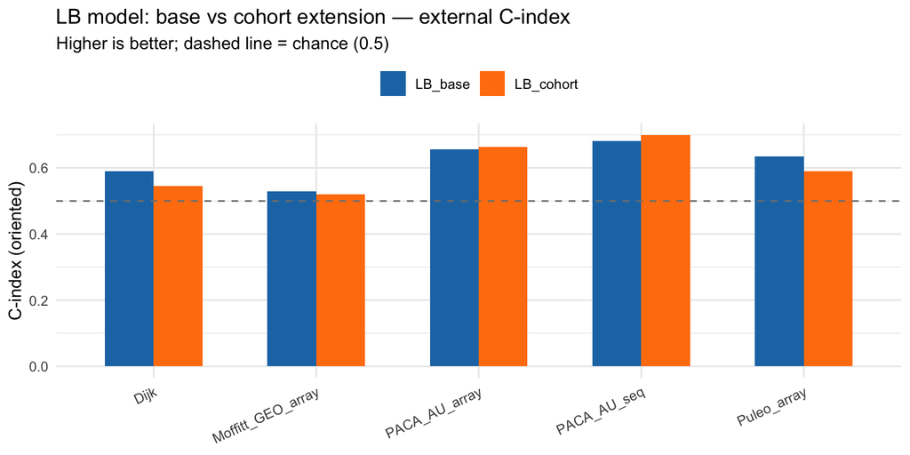

## Interpretation

The cohort extension produces **mixed results** that depend on the external cohort:

| Cohort | Platform | LB_cohort vs LB_base | Direction |
| --- | --- | --- | --- |
| Dijk | RNA-seq | 0.545 vs 0.590 | **−0.045** |
| Moffitt_GEO_array | Microarray | 0.520 vs 0.529 | −0.009 |
| PACA_AU_array | Microarray | 0.664 vs 0.657 | **+0.007** |
| PACA_AU_seq | RNA-seq | 0.700 vs 0.681 | **+0.019** |
| Puleo_array | Microarray | 0.590 vs 0.634 | **−0.044** |

# Comparison with Main Branch

## C-index

C-index comparison: main branch vs cohort-cols-L branch

| Cohort | Main LB | Branch LB_base | Branch LB_cohort |
| --- | --- | --- | --- |
| Dijk | 0.571 | 0.590 | 0.545 |
| Moffitt_GEO_array | 0.513 | 0.529 | 0.520 |
| PACA_AU_array | 0.648 | 0.657 | 0.664 |
| PACA_AU_seq | 0.671 | 0.681 | 0.700 |
| Puleo_array | 0.644 | 0.634 | 0.590 |
| MEAN | 0.609 | 0.618 | 0.604 |

## What Changed vs Main Branch

| Component | Main branch | Cohort-cols-L branch |
| --- | --- | --- |
| `code/update_F_cohort.R` | Does not exist | **New** — Normal conjugate update |
| `code/compute_elbo.R` | `compute_ebnm_kl`, `compute_survival_elbo` | **Added** `compute_normal_kl` |
| `code/fit_modular.R` | No cohort_id param | **Extended** — cohort_id, sigma_F_cohort |
| `code/fit_cox_on_yf.R` | No cohort_id param | **Extended** — same; ZF restricted to K cols |
| Test count | 209/209 | **229/229** (20 new cohort tests) |
| Backward compat | — | **Verified** — cohort_id=NULL ELBO bit-identical to pre-extension baseline |

# Limitations and Open Issues

## YFB β→0 on Merged Data

The most significant open issue is that the YFB model ($\eta = (YF)\beta$) collapses to $\beta = 0$ on merged TCGA+CPTAC regardless of the cohort indicator. The root cause is a scale imbalance in the $L$ update:
$$A_{\text{surv},ik} = \alpha \cdot W_{ii} \cdot \beta_k^2, \quad
A_{\text{gen},ik} = (1-\alpha) \cdot \tau_j \cdot \text{[genomics term]}$$
With $n=273$ samples and $p=2000$ genes, $A_\text{gen}$ summed over genes dwarfs $A_\text{surv}$ even at $\alpha=0.5$, driving the $L$ update toward a genomics-only optimum where $\beta \to 0$.

The cohort column contributes an additional source of genomics variance, which if anything makes this imbalance slightly worse. The per-platform z-standardization (Phase 1, DECISIONS.md 2026-05-06) resolved this for YFB_base by reducing $A_\text{gen}$ through better pre-normalization; the cohort-column approach does not.

## K_eff Trade-off

With $K=20$ and full convergence, ARD pruning reduces LB_base to $K_\text{eff}=3$ and LB_cohort to $K_\text{eff}=2$. The cohort indicator column “uses up” one factor of capacity. This trade-off is acceptable when $K_\text{eff} = 3$ would have included a platform factor anyway — but on PDAC merged data, the three LB_base factors appear to be genuinely biological (they transfer across platforms). Adding a cohort column forces ARD to settle for two biological factors, losing one prognostic program.

## Single Linear Offset Assumption

The CPTAC proteomics vs TCGA RNA-seq difference is not a rank-1 additive shift: different genes are affected differently, and the difference in measurement technology (abundance vs transcript count) produces non-linear effects. A single $f_c \in \mathbb{R}^p$ row per cohort can capture the mean-level shift but not higher-order platform effects.

# Proposed Solutions for YFB β→0 Collapse

The following solutions are ranked by expected benefit and implementation cost.

## Solution 1: Cox Warm-Start for YFB (Low effort, high probability of success)

The LB model already uses a Cox warm-start (`cox_warmstart=TRUE`): β is initialized by fitting a univariate Cox regression on the first $K$ principal components of $Y$. The YFB model currently uses `cox_warmstart=FALSE` (zero initialization) because computing $Z_F = Y \cdot F_\text{svd}$ requires a preliminary $F$, which is circular.

**Fix:** Use the SVD-initialized $F$ (available at the start of fitting) to compute $Z_F^\text{init} = Y \cdot F_0$, then fit a multivariate Cox on $Z_F^\text{init}$ to initialize $\beta$. This guarantees a non-trivial $\beta$ starting point, which the CAVI can then refine (rather than starting at the genomics-only zero-$\beta$ optimum).

```r
# Proposed change in fit_cox_on_yf.R init block:
if (cox_warmstart) {
  ZF_init <- Y %*% EF  # EF from SVD initialization
  cox_init <- tryCatch(
    coef(coxph(Surv(time, status) ~ ZF_init)),
    error = function(e) rep(0, K)
  )
  EBeta <- cox_init
}
```

## Solution 2: Per-Platform Preprocessing Before Cohort Column (Medium effort)

When `cohort_id` is provided, apply within-cohort z-standardization before merging (the Phase 1 fix for YFB_base, but applied as a preprocessing step within the fitting function). This ensures that the cohort indicator column captures only residual between-platform variance after z-standardization, reducing the magnitude of the platform offset that the CAVI must absorb.

This separates the two steps: (1) preprocessing removes most platform mean/variance differences, (2) the cohort indicator captures the residual. The result is a much smaller platform signal for the CAVI to contend with.

## Solution 3: Scaled α for Merged Multi-Platform Training (Low effort, uncertain benefit)

The current $\alpha = 0.5$ treats genomics and survival terms symmetrically in the ELBO. On merged TCGA+CPTAC ($n=273$, $p=2000$), the genomics term is approximately $n \cdot p = 546{,}000$ observations while survival has only $n = 273$. A pragmatic fix is to use a larger $\alpha$ for merged training:

$$\alpha_\text{merged} = \frac{p}{n + p} \approx \frac{2000}{2273} = 0.88$$

This would need careful validation (risk of overfitting $\beta$ to the survival signal) but represents the simplest tunable lever.

## Solution 4: β-Only Burn-In Iterations (Medium effort)

Hold $L$ and $F$ fixed and update $\beta$ alone for $N_\text{burnin}$ iterations at the start of fitting. This “reserves” the first iterations for the survival signal and ensures $\beta$ reaches a non-zero steady state before the genomics-dominated $L/F$ updates begin competing with it.

Previous experiments (EBMF warm-start, April 2026) showed $\beta \neq 0$ at iteration 1 under $\beta$-only update, but subsequent collapse in 23 iterations. The difference now is that the Phase C sign correction and the cohort column reduce the platform dominance, potentially making the $\beta$-only burn-in more stable.

## Solution 5: Per-Platform Noise Precision τ (High effort, structurally sound)

The CPTAC proteomics and TCGA RNA-seq noise variances ($1/\tau_j$) are almost certainly different. A shared $\tau_j$ estimated from the full merged matrix is dominated by the high-variance platform, inflating $A_\text{gen}$ and driving the imbalance. A per-platform $\tau_{j,c}$ would correctly model the heteroscedasticity and reduce the effective genomics weight in each cohort’s $L$ update.

This requires a new $q(\tau)$ derivation for the grouped case and non-trivial changes to `code/update_tau.R` and `code/fit_modular.R`. See `derivations/qTau/` for the current $q(\tau)$ derivation.

# Recommendations

## When to Use the Cohort Extension

Use `cohort_id` when:

1. **Low $K$ regime** ($K \leq 5$): At small $K$, the platform factor would otherwise dominate, leaving too few factors for biology. The cohort indicator allows the model to reach $K_\text{eff} > 0$ under short iteration budgets.
2. **Training cohorts differ in platform** (RNA-seq vs microarray vs proteomics): The benefit is greatest when the offset is a simple mean shift (RNA-seq vs microarray, both measuring transcript abundance).
3. **Short iteration budgets** (quick fits, CV folds): The cohort indicator helps the CAVI escape the genomics-only local minimum faster.

Do not expect the cohort extension to resolve $\beta \to 0$ in the YFB model on merged TCGA+CPTAC data. The YFB fix should come from better $\beta$ initialization (Solution 1 above) or preprocessing alignment (Solution 2).

## Next Steps

1. **Implement Cox warm-start for YFB** (`cox_warmstart=TRUE` using SVD-initialized $F$). This is the most promising near-term fix for YFB $\beta \to 0$.
2. **Test cohort extension at $K=5$** (run `run_cohort_lmm_benchmark.R` with `K_LB=5`, full convergence). The low-$K$ benefit hypothesis is testable immediately.
3. **Consider the preprocessing-first approach**: z-standardize within each cohort *before* fitting, then use `cohort_id` to capture residual between-platform effects.

# Appendix: Implementation Details

## Corner-Point Encoding

```r
# Cohort design matrix (C-1 columns; reference = first alphabetical level)
L_cohort <- model.matrix(~ factor(cohort_id))[, -1, drop = FALSE]
```

With $C=2$ cohorts (TCGA, CPTAC), this produces a single binary column: 1 for CPTAC, 0 for TCGA (reference). With $C=3$, two binary columns; and so on.

## Normal Conjugate Update for F_cohort

For cohort column $c$ and gene $j$, given residual $R_j^{(-c)} = Y_j - L F_j^\top - \sum_{c' \neq c} \ell_{c'} f_{c',j}$:

$$A_{cj} = \sigma_{F,c}^{-2} + n_c \hat{\tau}_j, \qquad
B_{cj} = \hat{\tau}_j \cdot \ell_c^\top R_j^{(-c)}$$
$$\mathbb{E}_q[f_{c,j}] = B_{cj}/A_{cj}, \qquad
\mathbb{E}_q[f_{c,j}^2] = (\mathbb{E}_q[f_{c,j}])^2 + 1/A_{cj}$$

## KL Contribution to ELBO

$$-\text{KL}\bigl[\mathcal{N}(\mu_{cj}, A_{cj}^{-1}) \,\|\, \mathcal{N}(0, \sigma_{F,c}^2)\bigr]
= \frac{1}{2}\left(1 - \frac{\mathbb{E}[f_{cj}^2]}{\sigma_{F,c}^2} - \log(A_{cj} \sigma_{F,c}^2)\right)$$

This quantity is negative (KL $\geq 0$) and is **added** to `elbo_full` by the caller — same sign convention as the EBNM KL terms.

## ZF Restriction (YFB Model)

In `fit_cox_on_yf.R`, ZF is computed from the $K$ biological columns only:

```r
# EF_aug = cbind(EF, EF_cohort)  [p × (K + C_cols)]
# ZF must use only columns 1:K (biological factors)
ZF <- Y %*% EF_aug[, seq_len(K), drop = FALSE]  # n × K
```